# The Good, The Bad, and The Ugly of the Beautiful Game

Debangan Dey, Andrew Pita

```r
library(dplyr)
library(ggplot2)
library(knitr)
library(purrr)
library(tidyverse)
library("jsonlite")
library(ggsoccer)
#library(plyr)
library(soccermatics)
library(sp)
library(spatstat)
library(lme4)
library(caret)
library(geometry)
library(spatial)
library(gridExtra)
```

# Motivation and Overview

In an era where data analysis is used to inform decision making in almost every domain of life, it is not surprising that it has taken a prominent place in the world of professional sports. Indeed, considering that professional sports are full of quantitative data (games won, points scored, yards rushed etc), and constitute a huge international industry, sports analytics can almost be considered a sub-field of bussiness intelligence.

Broadly, we define three areas in which data analysis can make (or already does make) a contribution to a professional sports organization: scouting for new players, optimizing game strategy, or providing real time in game recommendations.

One well known example of using data analysis to inform scouting is the performance of MLB’s Oakland Athletics in the 2002 season. Under the direction of General Manager Billy Beane, the Athletic’s organization used data analysis to develop measures that were predictive of future player performance and improved upon the current measures used by other teams. In doing so, they were able to use their limited funds to build a team that went on to win the American League West title. The strategy employed by the A’s in the 2002 season has been used and further developed with great success, playing a role in the 2004 Red Sox World Series victory, the 2016 Chicago Cubs World Series victory, and the 2017 Houston Astro’s World Series victory.

Increasingly, data analysis is being applied in the National Basketball Association and has fundamentally changed the way that coaches and managers structure their teams and approach the game. Decades ago, teams with tall and strong post players could dominate the game (see the Lakers three consecutive championships on the backs of Shaquile O’Neal and Kobe Bryant). Today, the most successful teams are built around three point shooting and speed in both ball movement and attacking. Players that we would think of as traditional “big men” can now also shoot from the perimeter, possessing more tools than they did in the past. This is in part due to increased athleticism and improved training on the part of the players, but also from an insight that if a player can shoot over a certain percentage from the three point line, it becomes an optimal strategy for them to take as many shots as possible.

Finally, we return to baseball to illustrate how teams now use data analysis in real time during the game to inform strategic decision making. Because the locations of all a batters previous successful hits can be stored digitally, constructing and updating a probability distribution of their hits during the game is an easy thing to accomplish. Many teams now do this and shift the position of their fielders so that they can optimally defend each specific batter.

In both professional basketball and soccer, leagues and teams have begun investing large sums of money in cameras and technology that provide not only the scoring and success percentage statistics that have always been used in the past, but also fine grained second by second information about where players and the ball are moving and how fast. This new high resolution spatio-temporal data presents new challenges in the field of sports analytics, as teams attempt to use this data to gain a competetive advantage over other teams.

In this project we attempt to utilize data collected by Stats Bomb during the 2018 FIFA World Cup as if we are data analysts for a soccer club, attempting to provide insights to the managers and coaching staff that can improve the teams play.

# Initial Questions

We began with mostly descriptive questions to get a feel for the data and to develop more questions. We list the specific questions below:

1. Where on the field most shots on goal came from? Do teams with different formations (the baseline positioning of the players on the field) take shots from locations at different frequencies?
2. What patterns of play give rise to the most effective shots? A play pattern describes the setting in which events of the game unfold. For example, if a team takes a shot that is saved and held on to by the goal keeper, then the next pattern of play begins with the keeper throwing or kicking the ball to one of his teammates. Other examples of patterns of play include play beginning from corner kicks, from throw ins, or from set pieces following a penalty.

In the course of our exploratory analysis we found that across all teams play patterns that began with the keeper on average led to shots with a higher XG value. We then changed the direction of this question, to investigate what keepers were doing that could explain this high mean XG.

3. Can we develop team level summary measures that are predictive of team performance? Data with such a fine grain of temporal detail can quickly become overwhelming. Summary measures such as these would be tremendously useful for a soccer club.

This question led to the development of a possession summary statistics that we used to predict both if a shot will take place, and what the XG value for that shot would be.

# Data

The data was downloaded here in JSON format and then processed with the R code below. We have it commented out so that it does not run when this file is knit, but we include it for completeness.

```r
# #Reading match data
# setwd("./data/matches")
# match.json.1 <- jsonlite::fromJSON(list.files()[1],flatten = TRUE)
# #Reading world cup data
# match.json.2 <- jsonlite::fromJSON(list.files()[2],flatten = TRUE)
# match.data <- rbind(match.json.1,match.json.2)[-1,]
#
#
# #Reading events datas
# event.path <- "../events"
# setwd(event.path)
#
# file.id <- list.files() %in% as.character(paste0(match.data[,1],".json"))
# file.list <- list.files()[file.id]
#
# event.data <- jsonlite::fromJSON(file.list[1], flatten = TRUE)
# event.data$match_id <- rep(as.numeric(substr(file.list[1],1,4)),nrow(event.data))
#
# for(i in 2:length(file.list)){
#   json.data <- jsonlite::fromJSON(file.list[i], flatten = TRUE)
#   match.id.event <- as.numeric(substr(file.list[i],1,4))
#   json.data$match_id <- rep(match.id.event,nrow(json.data))
#   event.data <- rbind.fill(event.data,json.data)
#   print(i)
# }
#
# all.data <- merge(event.data,match.data)
#
# #Splitting locations
# for(i in 1:nrow(all.data)){
#   if(is.null(all.data$location[[i]])){
#     all.data$start.x[i] <- NA
#     all.data$start.y[i] <- NA
#     all.data$pass.end.x[i] <- NA
#     all.data$pass.end.y[i] <- NA
#   } else if (is.null(all.data$pass.end_location[[i]])) {
#     all.data$start.x[i] <- all.data$location[[i]][1]
#     all.data$start.y[i] <- all.data$location[[i]][2]
#     all.data$pass.end.x[i] <- NA
#     all.data$pass.end.y[i] <- NA
#
#   } else {
#     all.data$start.x[i] <- all.data$location[[i]][1]
#     all.data$start.y[i] <- all.data$location[[i]][2]
#     all.data$pass.end.x[i] <- all.data$pass.end_location[[i]][1]
#     all.data$pass.end.y[i] <- all.data$pass.end_location[[i]][2]
#   }
# }
#
# #all.data$start.x <- all.data$location
#
# drops <- c("location","pass.end_location")
# all.data <- all.data[,!(names(all.data) %in% drops)]
#
# #write.csv(all.data,file="NWSL_event_compiled.csv")
#
# #Saving into .RData
# save(all.data,file="../Full_event_compiled.RData")
#
```

In all, this data contains 177,349 event obervations from 64 matches in the 2018 FIFA World Cup.

# Exploratory Data Analysis

```r
load("data/Full_event_compiled.RData")
```

To start let’s look into some descriptive type aspects of the data. Specifically, let’s get a feel for how many games, players, teams, shots, etc we have in this dataset.

```r
total_games = length(unique(all.data$match_id))
total_players = length(unique(all.data$player.name))
total_teams = length(unique(all.data$team.name))

total_shots = nrow(unique(all.data %>% filter(type.name == "Shot") %>%
  select(timestamp, type.name)))

total_goals = nrow(unique(all.data %>% filter(shot.outcome.name == "Goal") %>%
  select(timestamp, shot.outcome.name)))

totals = c(total_games,total_players,total_teams, total_shots, total_goals)
names(totals) = c("Games", "Players", "Teams", "Shots", "Goals")

kable(totals,col.names = "Total")
```

|  | Total |
| --- | --- |
| Games | 64 |
| Players | 605 |
| Teams | 32 |
| Shots | 1701 |
| Goals | 183 |

So we have data from 64 games, in which 605 players took part, on 32 different teams. The most interesting thing about this table though is the difference between the number of shots and the number of goals. Overall players are shooting at a success rate of only 11%!

Given that goals are such a rare event, we wonder whether or not shooting percentage is associated with the number of games a team wins. Below we explore that question.

```r
### seeing how many games each team won out of the total games they played

#as far as I can tell, home_score contains the final score for the home team in
#that game. away_score contains the same for the away team
wins_frame = all.data %>% select(match_id,  home_team.home_team_name,
                                 away_team.away_team_name, home_score, away_score)

#grouping by home_team.home_team_name and away_team.away_team_name then gives us
#individual games. The home_win column adds up the number of tiems the home team won,
#which will be inflated because the home_score has been placed at each timestamp. Same for
#away_win. We pass everything to distint at the end so we get the unique combinations

wins_frame = wins_frame %>% group_by(home_team.home_team_name, away_team.away_team_name) %>%
  mutate(home_win = sum(home_score > away_score),
         away_win = sum(home_score < away_score)) %>% distinct

#For each of the unique combinations that we have now, we simply want to put a 1
#in the home win column if the sum from last time is above zero. Same for the away_win
#column
wins_frame$home_win = ifelse(wins_frame$home_win > 0, 1, 0)
wins_frame$away_win = ifelse(wins_frame$away_win > 0, 1, 0)


#now for each team we want to loop through the
#wins_frame data frame and see how many home/away games they played,
#how many of those games they won, how many total games they played,
#and store all that information in an empty matrix
team_names = unique(all.data$team.name)
nloop = length(team_names)
wins_mat = matrix(nrow = nloop, ncol = 3)

for (i in 1:nloop) {

  team_name = team_names[i]
  team_home = wins_frame %>% filter(home_team.home_team_name == team_name)
  home_wins = sum(team_home$home_win)
  home_games = nrow(team_home)

  team_away = wins_frame %>% filter(away_team.away_team_name == team_name)
  away_wins = sum(team_away$away_win)
  away_games = nrow(team_home)

  wins = home_wins + away_wins

  wins_mat[i,1] = team_name
  wins_mat[i,2] = wins
  wins_mat[i,3] = home_games + away_games

}

#make the matrix a data frame and give it column names
team_wins_frame = as.data.frame(wins_mat)
colnames(team_wins_frame) = c("Team", "Wins", "Total Games")
#convert the columns to numeric
team_wins_frame$Wins = as.numeric(as.character(team_wins_frame$Wins))
team_wins_frame$`Total Games` = as.numeric(as.character(team_wins_frame$`Total Games`))
#calculate a win percentage for each team
team_wins_frame$win_percent = team_wins_frame$Wins/team_wins_frame$`Total Games`
```

```r
## getting a goal percentage for each team
#we are going to do a very similar loop to the one above

#first modify the original all.data frame to contain a column that
#contains the match_id along with each posession. Then convert timestamp
#to hours,minutes, seconds, and finally calculate a pass spead variable

all.data = all.data %>%
  mutate(match_pos=paste0(match_id,"_",possession),
            timehms=as.POSIXct(strptime(all.data$timestamp,format="%H:%M:%S")),
            pass.speed= pass.length/duration)

#construct a new dataframe which has summary statistics and also shows
#which team currently had possession
sum_possession_frame = all.data %>%
                #exclude timestamps corresponding to starting the match, half, etc
                      filter(!type.name %in% c("Starting XI","Half End",
                                      "Half Start","Camera On","Injury Stoppage",
                                      "Substitution","Tactical Shift")) %>%
                #group by the match_pos column that contains the match_id linked to the
                #posession number
                      group_by(match_pos) %>%
                #we want the new match id to have only one observation per match
                      summarise(match_id=unique(match_id),
                #the following are all summary statistics for the possession
                                passcount=sum(type.name=="Pass", na.rm = TRUE),
                                pass.under.pressure=sum(type.name=="Pass" & under_pressure== TRUE,
                                                        na.rm = TRUE),
                        #we again want only unique observations
                                match=unique(match_id),
                                possession= unique(possession),
                                poss.team=unique(possession_team.name),
                        #defending team is the home team column and the away team column
                        #where the away team is not in the home team column
                        #and the away team is not in possession of the ball
                                def.team=c(unique(home_team.home_team_name),
                        unique(away_team.away_team_name))[which(!c(unique(home_team.home_team_name),
                        unique(away_team.away_team_name)) %in% unique(possession_team.name))],

                              shot=sum(type.name=="Shot", na.rm = TRUE),
                              xG= mean(shot.statsbomb_xg, na.rm = TRUE),
                              goal=sum(shot.outcome.name=="Goal", na.rm = TRUE),
                              save = sum(shot.outcome.name == "Saved", na.rm = TRUE),
                              timespan=difftime(max(timehms[type.name!="Half Start"]),
                              min(timehms[type.name!="Half Start"]),unit="secs"),
                              time.under.pressure=sum(duration[type.name=="Pressure"], na.rm=TRUE),
                              pressurecount=sum(type.name=="Pressure"),

                              poss.team.score= c(unique(home_score),
                               unique(away_score))[which(c(unique(home_team.home_team_name),
                              unique(away_team.away_team_name)) %in% unique(possession_team.name))],

                              def.team.score=c(unique(home_score),

                        unique(away_score))[which(!c(unique(home_team.home_team_name),
          unique(away_team.away_team_name))%in%unique(possession_team.name))],half=unique(period)[1],

                            high.pass=sum(pass.height.name=="High Pass", na.rm = TRUE),
                            pass.length=mean(pass.length, na.rm = TRUE),
                            pass.speed=mean(pass.speed, na.rm = TRUE)) %>%

                    arrange(match,possession)


team_names = unique(sum_possession_frame$poss.team)
nloop = length(team_names)
goals_mat = matrix(nrow = nloop, ncol = 5)

for (i in 1:nloop) {

  team_name = team_names[i]
  team_frame = sum_possession_frame %>% filter(poss.team == team_name)
  shots = sum(team_frame$shot)
  goals = sum(team_frame$goal)

  team_frame = sum_possession_frame %>% filter(def.team == team_name)
  saved = sum(team_frame$save)
  total_attempts_against = sum(team_frame$shot)

  goals_mat[i, 1] = team_name
  goals_mat[i, 2] = shots
  goals_mat[i, 3] = goals
  goals_mat[i, 4] = saved
  goals_mat[i,5] = total_attempts_against
}

goals_frame = as.data.frame(goals_mat)
colnames(goals_frame) = c("Team", "Shots", "Goals","Saves","Shots_Against")
goals_frame$Team = as.character(goals_frame$Team)
goals_frame$Shots = as.numeric(as.character(goals_frame$Shots))
goals_frame$Goals = as.numeric(as.character(goals_frame$Goals))
goals_frame$Saves = as.numeric(as.character(goals_frame$Saves))
goals_frame$Shots_Against = as.numeric(as.character(goals_frame$Shots_Against))
goals_frame$shot_perc = goals_frame$Goals/goals_frame$Shots
goals_frame$save_perc = goals_frame$Saves/goals_frame$Shots_Against
```

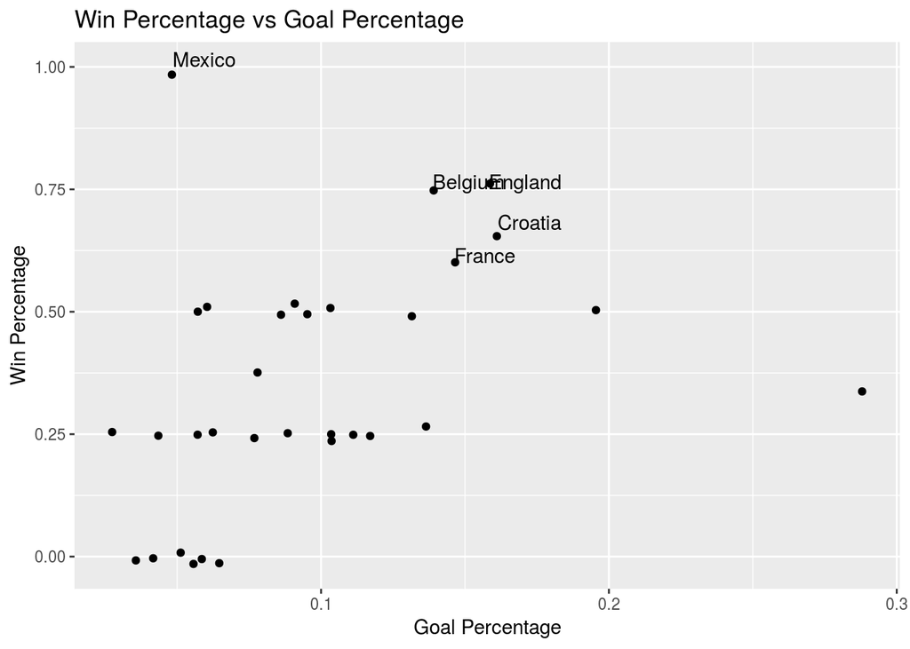

```r
#join team_wins_frame and goals_frame

teams_goals_wins = merge(goals_frame, team_wins_frame, by = "Team")

ggplot(data = teams_goals_wins, aes(x = shot_perc,y = win_percent)) +
  geom_jitter() +
  labs(x = "Goal Percentage", y = "Win Percentage",
       title = "Win Percentage vs Goal Percentage") +
  geom_text(aes(label = ifelse(win_percent > 0.5,Team,"")), hjust = 0, vjust = 0)
```

Next we want to explore some different characteristics of teams to see if they have any relationship with win percentage. We’ll start by looking at the average pass length.

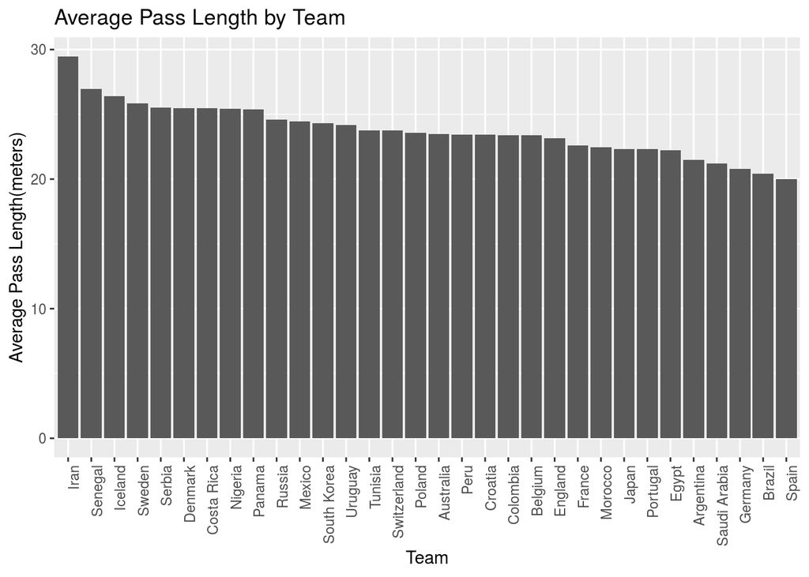

```r
pc.data= sum_possession_frame %>%
          mutate(timespan=as.numeric(timespan)) %>%
          select(match_id, match_pos,poss.team,def.team,passcount,
                 pass.under.pressure,timespan,time.under.pressure,high.pass,
                 pass.length,pass.speed, shot, goal, poss.team, def.team, xG) %>%
          filter(timespan >0)

r = rle(pc.data$poss.team)
pc.data$poss.run=rep(seq_along(r$lengths), r$lengths)
pc.norun= pc.data

possession_loc=function(x){
  poss.id=(pc.data[pc.data$poss.run==x,])$match_pos
  poss.team=unique((pc.data[pc.data$poss.run==x,])$poss.team)
  poss.loc = all.data %>% subset(match_pos %in% poss.id) %>% filter(type.name %in%
                                  c("Pass","Shot","Dribble") & team.name==poss.team) %>%
                        select(start.x,start.y)

  hpts <- chull(poss.loc$start.x, poss.loc$start.y)
  hpts <- c(hpts, hpts[1])
  ar <- polyarea(poss.loc[hpts,1],poss.loc[hpts,2])
  loc.goal <- rbind(poss.loc,c(120,40))
  d <- as.matrix(dist(loc.goal, diag=TRUE,upper=TRUE))
  d.goal <- d[nrow(loc.goal),][-nrow(loc.goal)]
  start <- c(head(poss.loc$start.x,1), head(poss.loc$start.y,1))
  end <- c(tail(poss.loc$start.x,1), tail(poss.loc$start.y,1))
  start1 <- start - c(120,40)
  end1 <- end - c(120,40)
  ang.goal <- acos(sum(start1*end1)/(sqrt(sum(start1^2)) * sqrt(sum(end1^2))))
  ang.play <- acos(abs(end[1] - start[1])/sqrt(sum((start-end)^2)))
  return(list(chull.area=ar,dist.to.goal=min(d.goal), ang.goal= ang.goal, ang.play=ang.play, vert.dist=end[1]-start[1]))

}

loc.data <- lapply(unique(pc.data$poss.run),function(x){tryCatch(possession_loc(x),error=function(e){rep(NA,5)})})
loc.cov <- t(matrix(unlist(loc.data),nrow=5))


pc.data <- pc.data %>% group_by(poss.run) %>%
        summarise(match_id=unique(match_id),breaks= n(),
                  timespan=sum(timespan,na.rm = TRUE),
                  time.under.pressure=sum(time.under.pressure,na.rm = TRUE),
                  shot=sum(as.numeric(shot), na.rm = TRUE),
                  goal=sum(as.numeric(goal), na.rm = TRUE),
                  pass.length=sum(passcount*pass.length,na.rm=TRUE)/sum(passcount, na.rm = TRUE),
                  pass.speed=sum(passcount*pass.speed,na.rm=TRUE)/sum(passcount, na.rm = TRUE),
                  poss.team=unique(poss.team),
                  def.team=unique(def.team),
                  high.pass=sum(high.pass, na.rm=TRUE),
                  pass.under.pressure= sum(pass.under.pressure, na.rm = TRUE),
                  xG=mean(xG,na.rm = TRUE), passcount=sum(passcount,na.rm=TRUE)) %>%
                  mutate(shot=factor(shot), goal=factor(goal))

pc.data <- data.frame(pc.data,chull.area=loc.cov[,1],dist.to.goal=loc.cov[,2],
                      ang.goal= loc.cov[,3], ang.play=loc.cov[,4], vert.dist=loc.cov[,5])


outlierreplacement <- function(dataframe){
  dataframe %>%
    map_if(is.numeric, ~ replace(.x, .x %in% boxplot.stats(.x, coef=5)$out, NA)) %>%
    bind_cols
}


pc.data.clean <- data.frame(pc.data %>%
                select(poss.run, poss.team, def.team, match_id,shot, goal, xG, timespan),
                          outlierreplacement(pc.data %>%
                select(time.under.pressure, pass.length, pass.speed, passcount,
                       pass.under.pressure,high.pass, chull.area, dist.to.goal, vert.dist)))

avg_pass_length = pc.data.clean %>%
      group_by(poss.team) %>%
      summarise(avg=mean(pass.length, na.rm=TRUE))

ggplot(data = avg_pass_length,aes(x=reorder(poss.team,-avg),y=avg)) +
  geom_bar(stat='identity') +
  theme(axis.text.x = element_text(angle = 90, hjust = 1)) +
  labs(x = "Team", y = "Average Pass Length(meters)", title = "Average Pass Length by Team")
```

So average pass length ranges from almost 30 meters to just over 20 meters. That’s not a huge difference, but I notice that some of the best teams have the shortest average pass length.

Now let’s examine how many passes a team on defense allows the opposing team on average.

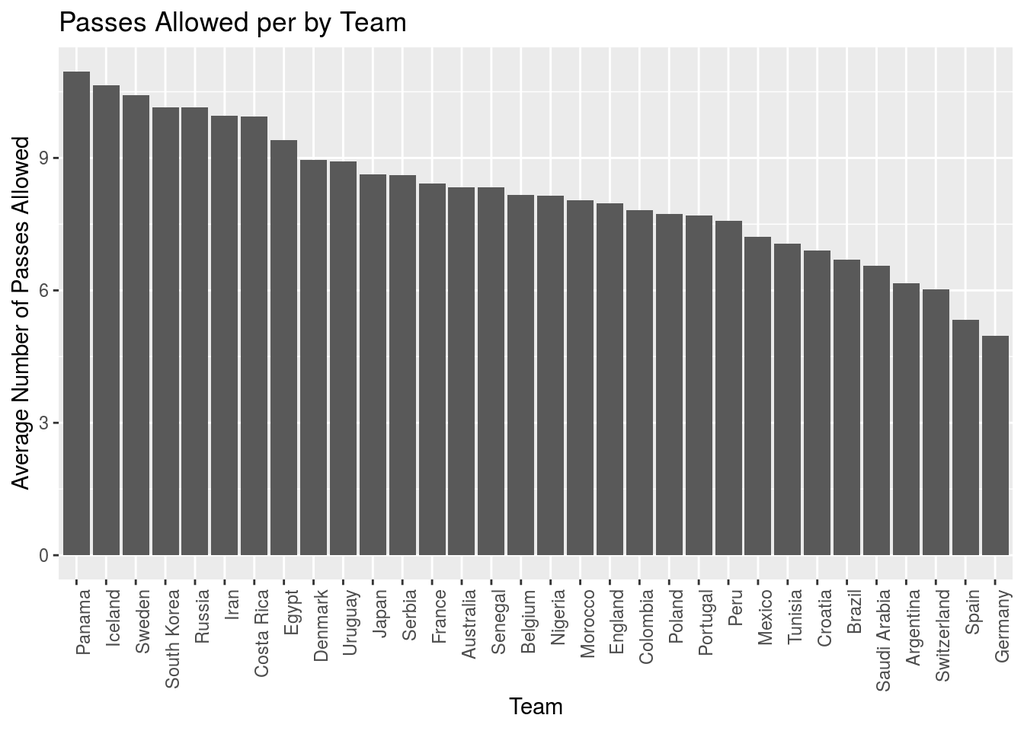

```r
avg_pass_allowed = pc.data.clean %>%
        group_by(def.team) %>%
        summarise(avg=mean(passcount, na.rm=TRUE))

ggplot(data = avg_pass_allowed, aes(x=reorder(def.team,-avg),y=avg)) +
  geom_bar(stat='identity') +
  theme(axis.text.x = element_text(angle = 90, hjust = 1)) +
  labs(x = "Team", y = "Average Number of Passes Allowed",
       title = "Passes Allowed per by Team")
```

It looks as though some of the more recognizable good teams have a small number of passes allowed on defense. This makes sense, as they are probably heavily pressuring the opposing team. This could be a useful team level defensive summary measure.

Finally, how do those two measures relate to win percentage?

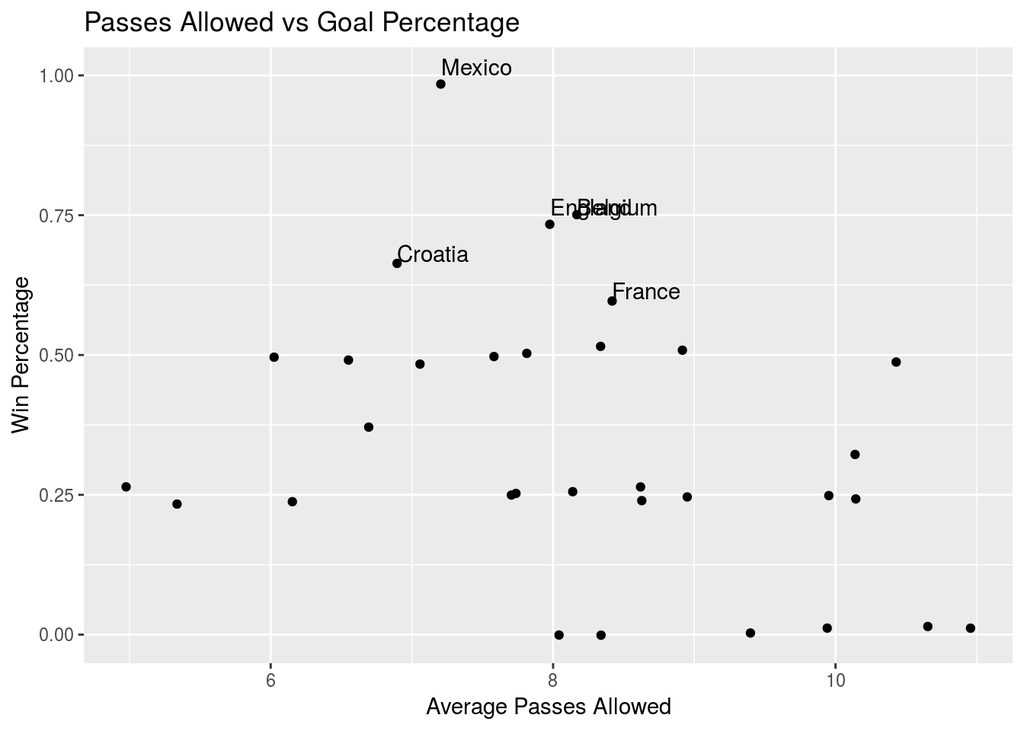

```r
colnames(avg_pass_allowed) = c("Team", "avg_pass")
teams_goals_wins = merge(teams_goals_wins, avg_pass_allowed, by = "Team")

ggplot(data = teams_goals_wins, aes(x = avg_pass,y = win_percent)) +
  geom_jitter() +
  labs(x = "Average Passes Allowed", y = "Win Percentage",
       title = "Passes Allowed vs Goal Percentage") +
  geom_text(aes(label = ifelse(win_percent > 0.5,Team,"")), hjust = 0, vjust = 0)
```

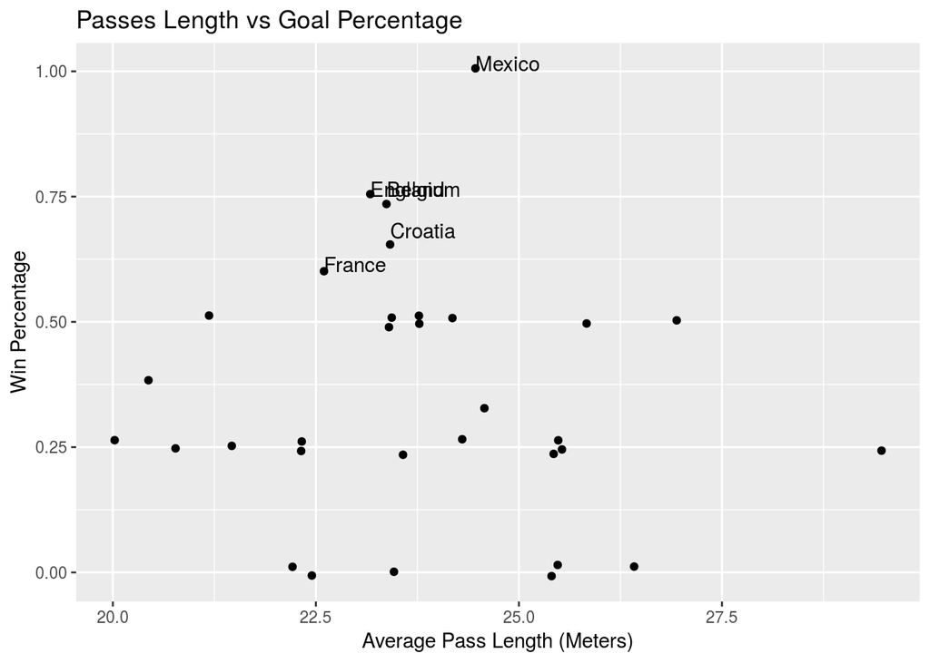

```r
colnames(avg_pass_length) = c("Team", "avg_length")
teams_goals_wins = merge(teams_goals_wins, avg_pass_length, by = "Team")

ggplot(data = teams_goals_wins, aes(x = avg_length,y = win_percent)) +
  geom_jitter() +
  labs(x = "Average Pass Length (Meters)", y = "Win Percentage",
       title = "Passes Length vs Goal Percentage") +
  geom_text(aes(label = ifelse(win_percent > 0.5,Team,"")), hjust = 0, vjust = 0)
```

As stated in the initial questions section, we are interested in seeing if certain play patterns give rise to more effective shots on goal. Included in this dataset is a measure called XG (excpected goal), which is calculated and provided by STATSBomb. It is designed to be a measure of the likelihood of a goal for any shot. Here we will look at differences in the mean XG and also successful goal percentage for shots taking place in different play patterns.

```r
## data frame contain only shot events
shots = all.data %>% filter(type.name == "Shot") %>%
        select(match_id, timestamp, type.name, under_pressure,
                   play_pattern.name, shot.statsbomb_xg, shot.outcome.name,
                   goalkeeper.position.name, shot.deflected)

#group by the type of play pattern in which the goal took place
#mean xg for each type calculated
play_pattern_mean_xg = shots %>% group_by(play_pattern.name) %>%
  summarise(mean_xg = mean(shot.statsbomb_xg),
            sd_xg = sd(shot.statsbomb_xg),
            n_goal = sum(shot.outcome.name == "Goal"),
            n_missed = sum(shot.outcome.name != "Goal"),
            prop_goal = n_goal/(n_missed + n_goal))

play_pattern_for_plot = shots  %>%
              select(play_pattern.name, shot.statsbomb_xg)



#now look at the same thing but simply shots on target
shots_on_target_mean_xg = shots %>% group_by(play_pattern.name) %>%
  summarise(mean_xg = mean(shot.statsbomb_xg),
            sd_xg = sd(shot.statsbomb_xg),
            n_ontarget = sum(shot.outcome.name == "Goal" | shot.outcome.name == "Blocked" |
                           shot.outcome.name == "Saved"),
            n_total = n(),
            prop_on = n_ontarget/(n_total))
```

Now let’s visualize these results.

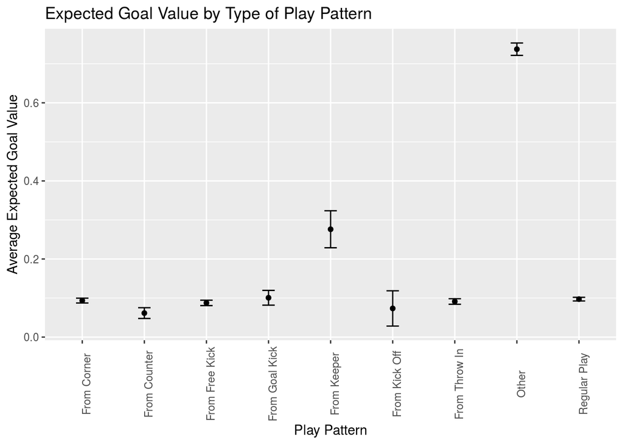

```r
ggplot(data = play_pattern_for_plot, aes(x = play_pattern.name, y = shot.statsbomb_xg)) +
  stat_summary(fun.y = mean, geom = "point") +
  stat_summary(fun.data = mean_se, geom = "errorbar", aes(width = 0.2)) +
  theme(axis.text.x = element_text(angle = 90)) +
  labs(x = "Play Pattern", y = "Average Expected Goal Value",
       title = "Expected Goal Value by Type of Play Pattern")
```

The “other” play pattern corresponds to penalty kicks, which is why it’s XG value is so much higher. The other play patterns have very similar XG values, except for the from keeper play pattern. This play pattern begins when a keeper gains control of the ball and then puts the ball back into play, which is very interesting because it implies that attacking too strongly can have a negative outcome if the keeper manages to gain control of the ball.

Below we further investigate the relationship between play pattern and XG by calculatting an average XG by play pattern for each team, and then using PCA to cluster teams along their first two principal components.

```r
team_name = team_names[1]
team_xg = all.data %>% filter(possession_team.name == team_name, type.name == "Shot") %>%
        select(play_pattern.name, shot.statsbomb_xg, shot.outcome.name) %>%
        group_by(play_pattern.name) %>%
        summarise(mean_xg = mean(shot.statsbomb_xg),
            sd_xg = sd(shot.statsbomb_xg),
            n_goal = sum(shot.outcome.name == "Goal"),
            n_missed = sum(shot.outcome.name != "Goal"),
            prop_goal = n_goal/(n_missed + n_goal))


row1 = c(team_name, team_xg[1,2:ncol(team_xg)], team_xg[2,2:ncol(team_xg)],
         team_xg[3,2:ncol(team_xg)], team_xg[4,2:ncol(team_xg)],
         team_xg[5,2:ncol(team_xg)], team_xg[6,2:ncol(team_xg)],
         team_xg[7,2:ncol(team_xg)],team_xg[8,2:ncol(team_xg)])
names(row1) = c("team","mean_corner_xg", "sd_corner_xg", "n_corner_goal", "n_corner_missed",
                "prop_corner","mean_freekick_xg","sd_freekick_xg","n_freekick_goal",
                "n_freekick_missed","prop_freekick", "mean_goalkick_xg",
                "sd_goalkick_xg","n_goalkick_goal","n_goalkick_missed","prop_goalkick",
                "mean_keep_xg","sd_keep_xg", "n_keep_goal", "n_keep_missed","prop_keep",
                "mean_kickoff_xg", "sd_kickoff_xg", "n_kickoff_goal", "n_kickoff_missed",
                "prop_kickoff", "mean_throwin_xg","sd_throwin_xg","n_throwin_goal",
                "n_throwin_missed", "prop_throwin", "mean_pk_xg", "sd_pk_xg","n_pk_goal",
                "n_pk_missed","prop_pk", "mean_regular_xg", "sd_regular_xg", "n_regular_goal",
                "n_regular_missed", "prop_regular")

for (i in 2:nloop) {

  team_name = team_names[i]
  loop_xg = all.data %>% filter(possession_team.name == team_name, type.name == "Shot") %>%
        select(play_pattern.name, shot.statsbomb_xg, shot.outcome.name) %>%
        group_by(play_pattern.name) %>%
        summarise(mean_xg = mean(shot.statsbomb_xg),
            sd_xg = sd(shot.statsbomb_xg),
            n_goal = sum(shot.outcome.name == "Goal"),
            n_missed = sum(shot.outcome.name != "Goal"),
            prop_goal = n_goal/(n_missed + n_goal))

  rowloop = c(team_name, loop_xg[1,2:ncol(loop_xg)], loop_xg[2,2:ncol(loop_xg)],
         loop_xg[3,2:ncol(loop_xg)], loop_xg[4,2:ncol(loop_xg)],
         loop_xg[5,2:ncol(loop_xg)], loop_xg[6,2:ncol(loop_xg)],
         loop_xg[7,2:ncol(loop_xg)],loop_xg[8,2:ncol(loop_xg)])

  names(rowloop) = c("team","mean_corner_xg", "sd_corner_xg", "n_corner_goal", "n_corner_missed",
                "prop_corner","mean_freekick_xg","sd_freekick_xg","n_freekick_goal",
                "n_freekick_missed","prop_freekick", "mean_goalkick_xg",
                "sd_goalkick_xg","n_goalkick_goal","n_goalkick_missed","prop_goalkick",
                "mean_keep_xg","sd_keep_xg", "n_keep_goal", "n_keep_missed","prop_keep",
                "mean_kickoff_xg", "sd_kickoff_xg", "n_kickoff_goal", "n_kickoff_missed",
                "prop_kickoff", "mean_throwin_xg","sd_throwin_xg","n_throwin_goal",
                "n_throwin_missed", "prop_throwin", "mean_pk_xg", "sd_pk_xg","n_pk_goal",
                "n_pk_missed","prop_pk", "mean_regular_xg", "sd_regular_xg", "n_regular_goal",
                "n_regular_missed", "prop_regular")




  row1 = rbind(row1, rowloop)

}

team_xg = as.data.frame(row1)
rownames(team_xg) = NULL
```

```r
#PCA by xg and play pattern name
team_xg_scaled = team_xg[,grepl(pattern = "mean",x = colnames(team_xg))]
team_xg_scaled = team_xg_scaled[,-ncol(team_xg_scaled)]

team_xg_scaled = apply(team_xg_scaled,2,as.numeric)
team_xg_scaled = scale(team_xg_scaled, center = TRUE, scale = TRUE)
rownames(team_xg_scaled) =  team_xg$team
xgPC = prcomp(na.omit(team_xg_scaled))
summary(xgPC)
```

```
## Importance of components:
##                           PC1    PC2    PC3    PC4     PC5    PC6     PC7
## Standard deviation     1.4449 1.1514 1.0979 0.9689 0.75566 0.5659 0.44103
## Proportion of Variance 0.3143 0.1996 0.1815 0.1413 0.08595 0.0482 0.02928
## Cumulative Proportion  0.3143 0.5138 0.6953 0.8366 0.92252 0.9707 1.00000
```

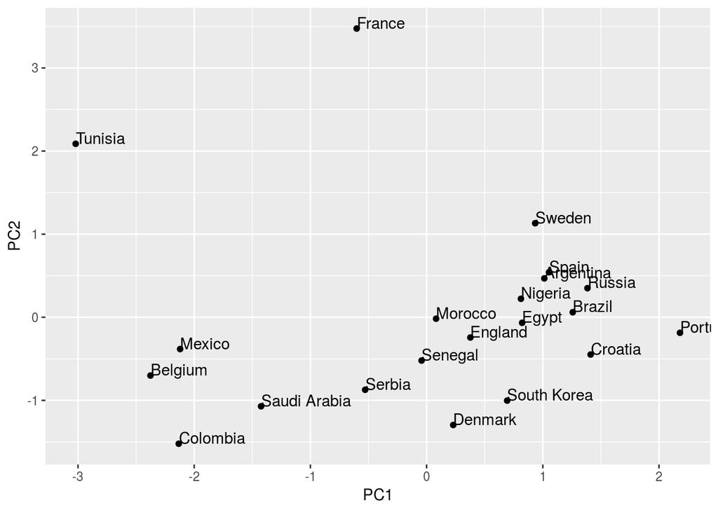

```r
forPlot = data.frame(PC1 = xgPC$x[,1], PC2 = xgPC$x[,2])
forPlot$team = rownames(xgPC$x)

ggplot(data = forPlot, aes(x = PC1,y = PC2)) +
  geom_point() +
  geom_text(aes(label = team),hjust = 0, vjust = 0)
```

It looks like a good number of teams cluster on the right side, but what is going on with France?

```r
france_xg = all.data %>% filter(possession_team.name == "France", type.name == "Shot") %>%
        select(play_pattern.name, shot.statsbomb_xg, shot.outcome.name) %>%
        group_by(play_pattern.name) %>%
        summarise(mean_xg = mean(shot.statsbomb_xg),
            sd_xg = sd(shot.statsbomb_xg),
            n_goal = sum(shot.outcome.name == "Goal"),
            n_missed = sum(shot.outcome.name != "Goal"),
            prop_goal = n_goal/(n_missed + n_goal))

france_xg
```

```
## # A tibble: 7 x 6
##   play_pattern.name mean_xg   sd_xg n_goal n_missed prop_goal
##   <chr>               <dbl>   <dbl>  <int>    <int>     <dbl>
## 1 From Corner        0.113   0.0960      1        5    0.167
## 2 From Free Kick     0.0566  0.0514      1       17    0.0556
## 3 From Goal Kick     0.388  NA           0        1    0
## 4 From Keeper        0.0212  0.0128      0        2    0
## 5 From Throw In      0.0910  0.0964      1        7    0.125
## 6 Other              0.76    0           3        0    1
## 7 Regular Play       0.119   0.159       6       38    0.136
```

```r
play_pattern_mean_xg
```

```
## # A tibble: 9 x 6
##   play_pattern.name mean_xg  sd_xg n_goal n_missed prop_goal
##   <chr>               <dbl>  <dbl>  <int>    <int>     <dbl>
## 1 From Corner        0.0935 0.104      23      255    0.0827
## 2 From Counter       0.0614 0.0661      0       23    0
## 3 From Free Kick     0.0875 0.119      23      278    0.0764
## 4 From Goal Kick     0.101  0.120       1       39    0.025
## 5 From Keeper        0.276  0.303      10       31    0.244
## 6 From Kick Off      0.0734 0.157       0       12    0
## 7 From Throw In      0.0912 0.110      21      219    0.0875
## 8 Other              0.737  0.123      43       17    0.717
## 9 Regular Play       0.0972 0.125      62      649    0.0872
```

So France has an unusually large mean XG for play patterns beginning with a goal kick, although they only took one shot from such a play pattern. Perhaps this one dataset is not sufficient to explain the phenomena of high XG in play patterns beginning with the keeper. But we do note that a goal kick is another from of play originating from the keeper.

# Data Analysis

### Question 1

Where on the field most shots on goal came from? Do teams with different formations (the baseline positioning of the players on the field) take shots from locations at different frequencies? Is losing ball at certain locations more harmful for certain formations?

From the World Cup 2018 events data, we focus on location information related to shots to answer this question.We have every event location on the field recorded as coordinates inside the $[0,120] * [0,80]$ rectangle. Let $S_{ij}$ be the location of the $i$-th shot and $T_{ij}$ be the location of the turnover which led to $i$-th shot when the defending team was employed in $j$-th kind of formation. We didn’t find any possession lasting more than 2 minutes, so, we first filter out data from 2-minute window before shot to find out the turnover location from which the attacking team took possession of the ball.

```r
###Storing which position id means what
position.info <- all.data %>% select(position.id,position.name) %>% unique
position.info <- position.info[-1,]
position.info <- position.info %>% arrange(position.id)


###Getting player positions and formation matchwise
position.data <- data.frame(player.id=numeric(), player.name=character(), position.name=character(),
                            match_id= numeric(), team.id=numeric(), team.name=numeric(),tactics.formation=numeric(),
                            team.status=character())

for (i in unique(all.data$match_id)){
  all.data.match <- all.data %>% filter(match_id==i)
  team1.id=all.data.match[1,]$team.id
  team1.name = all.data.match[1,]$team.name
  team1.formation=all.data.match[1,]$tactics.formation

  team2.id=all.data.match[2,]$team.id
  team2.name = all.data.match[2,]$team.name
  team2.formation=all.data.match[2,]$tactics.formation

  position.data <- rbind(position.data, data.frame(all.data.match$tactics.lineup[[1]][,c(2,3,5)],match_id=i, team.id=team1.id,team.name=team1.name,tactics.formation=team1.formation, team.status="Home"))
  position.data <- rbind(position.data, data.frame(all.data.match$tactics.lineup[[2]][,c(2,3,5)],match_id=i,team.id=team2.id,team.name=team2.name,tactics.formation=team2.formation, team.status="Away"))
}

######Shots data


shots.sub <-   all.data[,which(unlist(lapply(names(all.data),function(x){grepl(pattern="shot",x)})))]

shots.data <- cbind(all.data %>% select(match_id, index, period, timestamp, minute, second, player.id, team.id, start.x, start.y, play_pattern.name, type.name),
                    shots.sub)

shots.data <- shots.data[!is.na(shots.data$shot.statsbomb_xg),]

###### Getting m minute data before shots ########
m <- 2
shots.pre <- list()

for(i in 1:nrow(shots.data)){
  shot.time <- strptime(shots.data$timestamp[i],format="%H:%M:%S")
  shot.period <- shots.data$period[i]
  all.data.shot <- subset(all.data,match_id==shots.data[i,]$match_id)
  all.data.shot$timestamp <- strptime(all.data.shot$timestamp,format="%H:%M:%S")
  shots.pre[[i]] <- subset(all.data.shot, as.numeric(timestamp - shot.time) <= 0 & as.numeric(timestamp - shot.time) > (-60*m) & period == shot.period & index <= shots.data$index[i])
}

res.x <- 30
res.y <- 16

D <- data.frame(x=runif(1000,0,120), y=runif(1000,0,80))
D <- within(D, {
  grp.x = cut(x, seq(0,120,by=res.x), labels = FALSE)
  grp.y = cut(y, seq(0,80,by=res.y), labels = FALSE)
}) %>% select(grp.x,grp.y) %>% mutate(grid.ind=paste0(grp.x,"_",grp.y))

D$grid.ind <- factor(D$grid.ind)

####attributes from shots m-minute window
shotwindow.att <- function(i){
  shot.info <- tail(shots.pre[[i]],1)
  shot.possession <- subset(shots.pre[[i]], possession == shot.info$possession)
  attack.team <- shot.info$team.name
  defend.team <- c(shot.info$home_team.home_team_name,shot.info$away_team.away_team_name)[!(c(shot.info$home_team.home_team_name,shot.info$away_team.away_team_name) %in% shot.info$team.name)]
  tactics.flag.defence <- subset(all.data, (match_id== shot.info$match_id & team.name==defend.team & type.name == "Tactical Shift" & period < shot.info$period) | (match_id== shot.info$match_id & team.id == shot.info$team.id & type.name == "Tactical Shift" & period == shot.info$period & minute <= shot.info$minute & second < shot.info$second))
  tactics.flag.attack <- subset(all.data, (match_id== shot.info$match_id & team.name==attack.team & type.name == "Tactical Shift" & period < shot.info$period) | (match_id== shot.info$match_id & team.id == shot.info$team.id & type.name == "Tactical Shift" & period == shot.info$period & minute <= shot.info$minute & second < shot.info$second))
  attack.formation <- ifelse(nrow(tactics.flag.attack)>0,tail(tactics.flag.attack$tactics.formation,1),unique(subset(position.data, team.id == shot.info$team.id & match_id == shot.info$match_id)$tactics.formation))
  defence.formation <- ifelse(nrow(tactics.flag.defence)>0,tail(tactics.flag.defence$tactics.formation,1),unique(subset(position.data, team.id != shot.info$team.id & match_id == shot.info$match_id)$tactics.formation))
  time.to.shoot <- as.numeric(shot.info$timestamp - shot.possession$timestamp[1])
  distance.to.shot <- as.numeric(dist(rbind(c(shot.info$start.x,shot.info$start.y), c(shot.possession$start.x[1], shot.possession$start.y[1]))))
  speed.of.attack <- distance.to.shot/time.to.shoot
  shot.xG <- shot.info$shot.statsbomb_xg
  pressure.escaped <- nrow(subset(shot.possession, type.name=="Pressure"))

  # if(shot.info$start.x > 60){
  #   shot.possession$start.x= abs(shot.possession$start.x - 120)
  #   shot.possession$start.y= abs(shot.possession$start.y - 80)
  # }

  location.grid <- within(shot.possession, {
    grp.x = cut(start.x, seq(0,120,by=res.x), labels = FALSE, include.lowest = TRUE)
    grp.y = cut(start.y, seq(0,80,by=res.y), labels = FALSE, include.lowest = TRUE)
  }) %>% select(grp.x,grp.y) %>% mutate(grid.ind=paste0(grp.x,"_",grp.y))

  shot.possession <- data.frame(shot.possession,location.grid)
  shot.possession$grid.ind <- factor(shot.possession$grid.ind, levels=levels(D$grid.ind))

  pressure.location <-unlist((shot.possession %>% select(-timestamp) %>% filter(type.name=="Pressure")%>% group_by(grid.ind) %>%
                                  summarise(pressure.count=n()) %>% complete(grid.ind, fill = list(pressure.count= 0)))[,2])

  pass.location <-unlist((shot.possession %>% select(-timestamp) %>% filter(type.name=="Pass")%>% group_by(grid.ind) %>%
    summarise(pass.count=n()) %>% complete(grid.ind, fill = list(pass.count= 0)))[,2])

  win.location <- head(shot.possession$grid.ind,1)
  win.x= as.numeric(na.omit(shot.possession$start.x)[1])
  win.y= as.numeric(na.omit(shot.possession$start.y)[1])

  covars <- t(data.frame(c(AT=attack.team,DT=defend.team,AF=attack.formation, DF=defence.formation,time.to.shoot=time.to.shoot, distance.to.shot=distance.to.shot, speed=speed.of.attack, xG=shot.xG, n.pressure=pressure.escaped, unlist(pressure.location), unlist(pass.location))))
  covars <- cbind(covars,win.x,win.y,win.location)
  return(covars)
}

###recording 2 minute frames from all shotwindows
shots.att <- unlist(shotwindow.att(1))

for(i in 2:nrow(shots.data)){
  temp <- rbind(shots.att,shotwindow.att(i))
  shots.att <- temp
  #print(i)
}

shots.full <- data.frame(shots.data,shots.att[,c(1,2)],apply(shots.att[,-c(1,2)],2,as.numeric))
shots.full$Goal <- shots.full$shot.outcome.name == "Goal"
shots.full$win.location <- relevel(factor(shots.full$win.location), ref=20)
shots.full$win.x <- as.numeric(shots.full$win.x)
shots.full$win.y <- as.numeric(shots.full$win.y)
shots.full$distance.to.shot <- as.numeric(shots.full$distance.to.shot)
```

We remove shots corresponding to formations which have less than 15 shots associated with it to ensure we have significant data for a formation to draw associations. We also consider shots which came from open play only. This leaves out set piece or penalty situations when the shot or turnover locations can be determined by factors other than team compositions.

```r
formation.interest=as.numeric(names(table(shots.full$DF)[which(table(shots.full$DF) > 15)]))
#### Fitting PPM to ball win location data
shots.full1= shots.full %>% filter(play_pattern.name=="Regular Play" & DF %in% formation.interest)
```

To investigate if there are different patterns of turnover and shot locations for different defensive team formation, we model the locations data using a marked Poisson point process with the marks being the formation. To adjust for the team or player effect, I adjust the non-homogeneous intensity function of the point process to the surface of expected goals (xG) from a specific turnover location. We model the intensity function for shots ($\lambda_S$) and turnovers ($\lambda_T$) as follows -

$$\lambda_S(x_i,y_i) = F_i * poly(x_i,|y_i-40|,2)$$
$$log(\lambda_T(x_i,y_i)) = log(F_i * poly(x_i,|y_i-40|,2)) + log(Z(x_i,|y_i-40|))$$

where $Z(x_i,y_i)$ is the estimated expected goals surface for turnover locations. We take absolute value of the $y$ axis co-ordinates as we expect the inherent pattern to be symmetric with respect to $x$-axis on the soccer field.

```r
PP <- ppp(as.numeric(shots.full1$win.x), as.numeric(shots.full1$win.y), c(0,120),c(0,80), marks=factor(shots.full1$DF))
# covar <- function(x,y,marks){
#   return(subset(shots.full,win.x==x & win.y==y & DF==marks)$distance.to.shot[1])
# }
##fitting surface for xG over ball win location
fit.sfc2 <- surf.ls(2, data.frame(x=shots.full1$win.x,y=shots.full1$win.y,z=shots.full1$xG))
trsurf <- trmat(fit.sfc2, 0, 120, 0, 80, 80)
cov <- as.im(list(x=trsurf$x,y=trsurf$y,z=trsurf$z),W=Window(PP))
g <- function(y){abs(y-40)}
fit=ppm(PP ~  marks*polynom(x,g(y),2) + offset(log(Z)), Poisson(), covariates=list(Z=cov))

#covar <- shots.full %>% select(DF,distance.to.shot,time.to.shoot,xG,speed) %>% mutate(DF=factor(DF))
pred <- predict(fit, ngrid=c(80,120), type="cif")

## Fitting PPM to shot location data
PP.shot <- ppp (as.numeric(shots.full1$start.x), as.numeric(shots.full1$start.y), c(0,120),c(0,80), marks=factor(shots.full1$DF))
fit.shot=ppm(PP.shot ~  marks * polynom(x,y,2), Poisson())

pred2 <- predict(fit.shot,ngrid=c(80,120), type="cif")
```

Once we get the predicted surface,

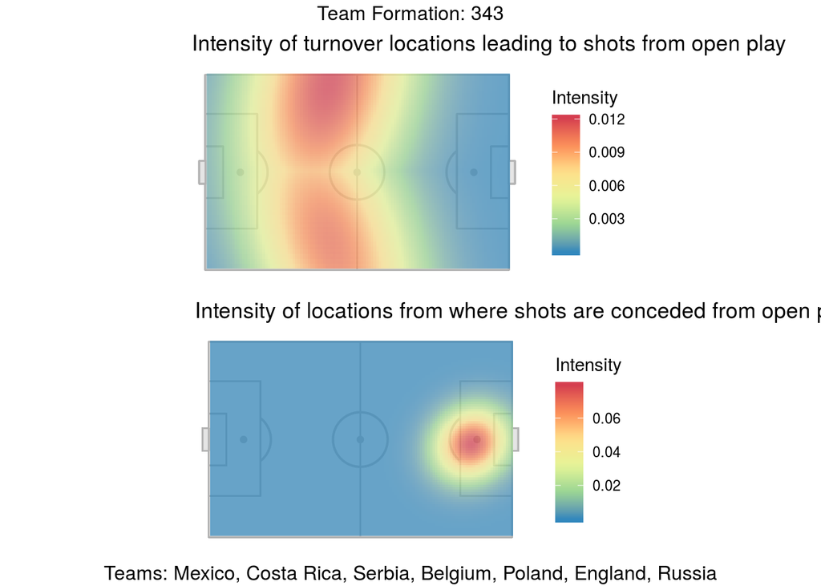

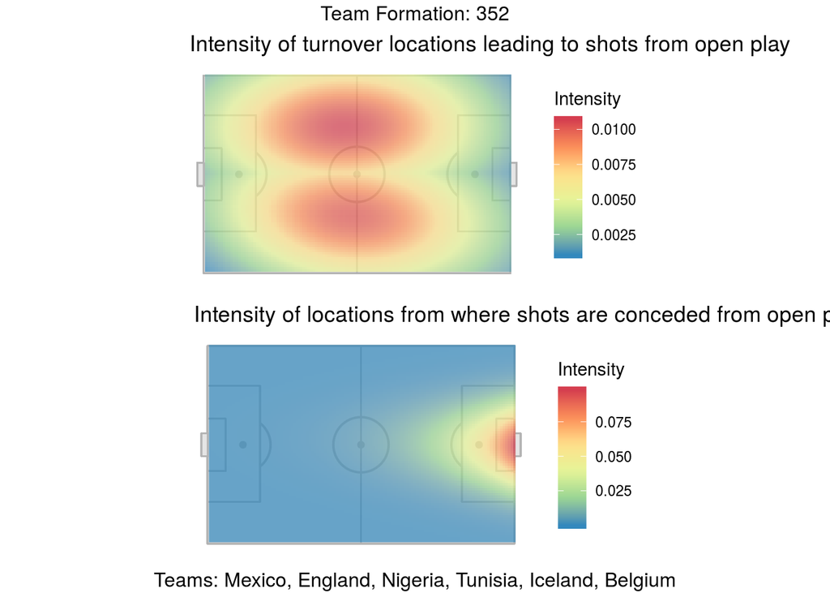

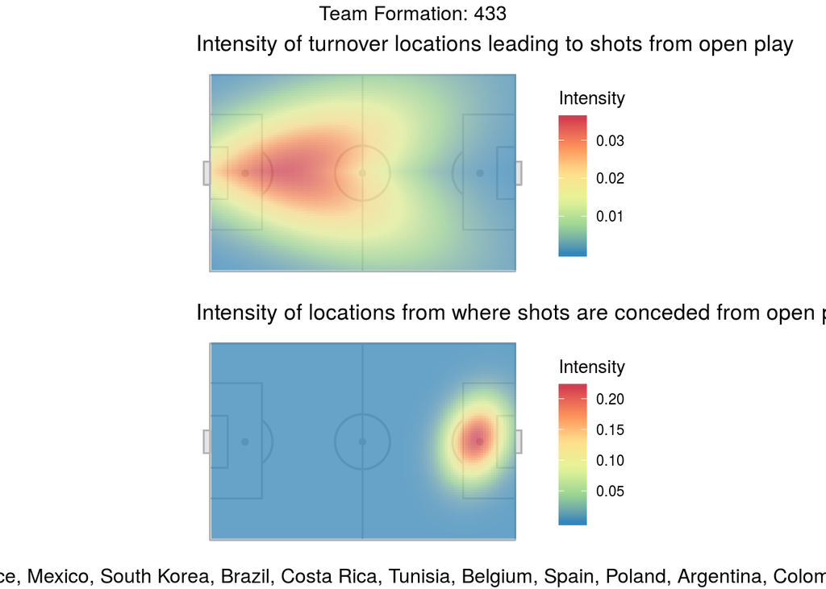

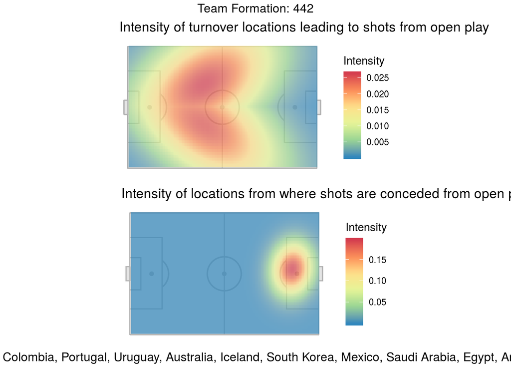

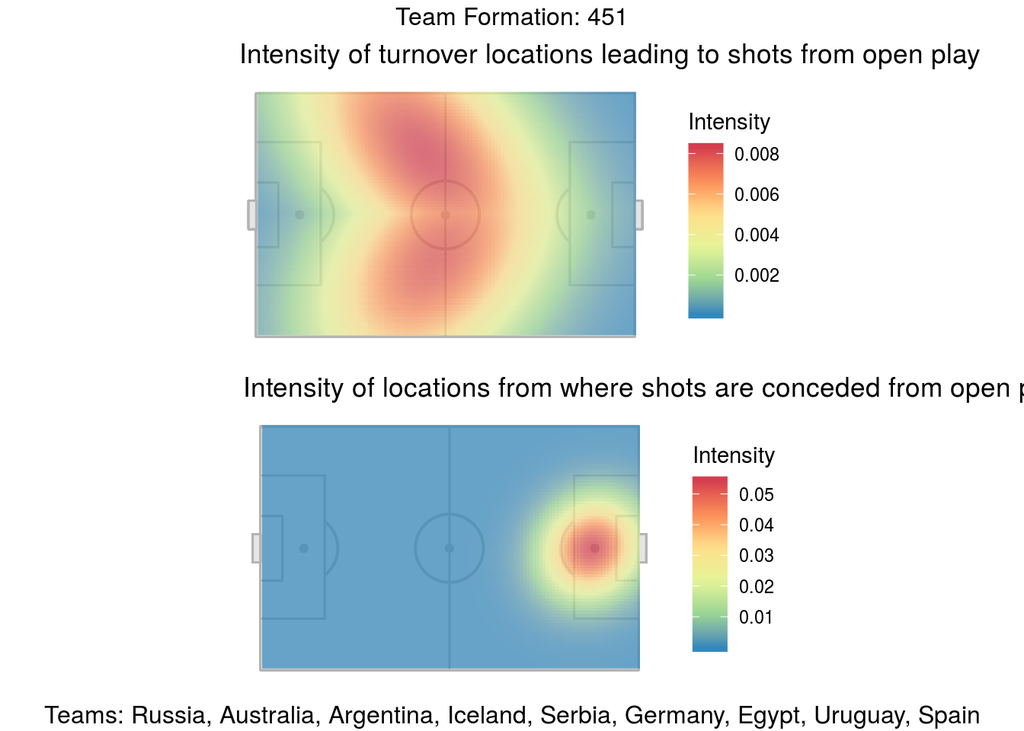

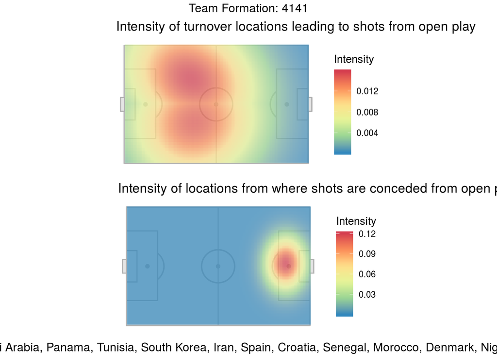

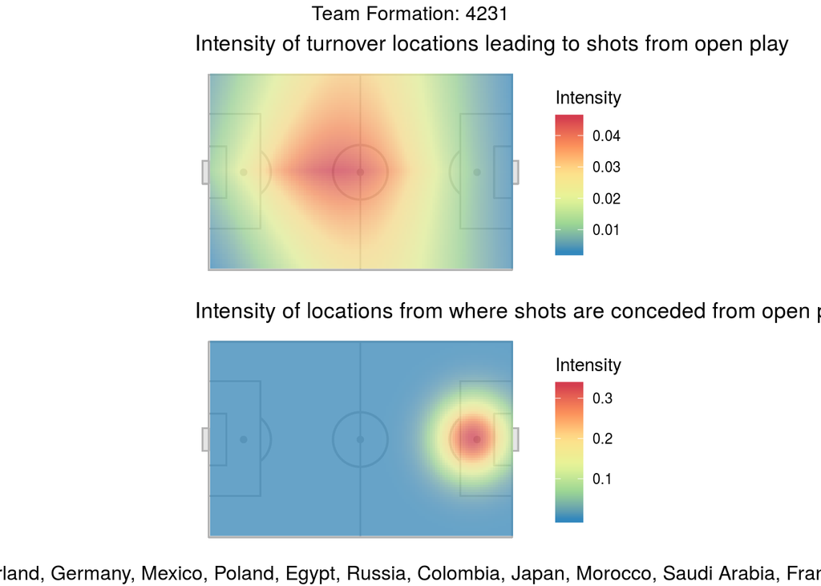

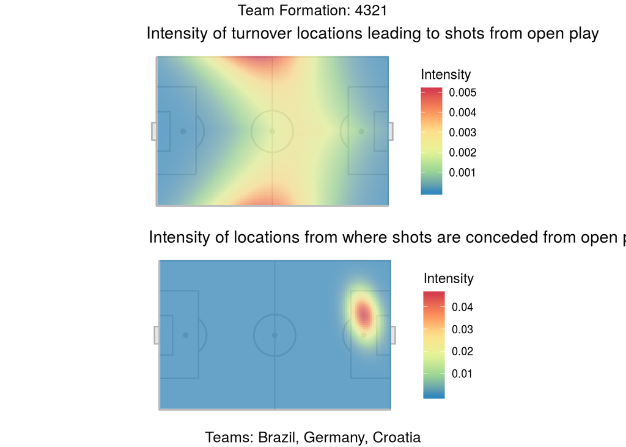

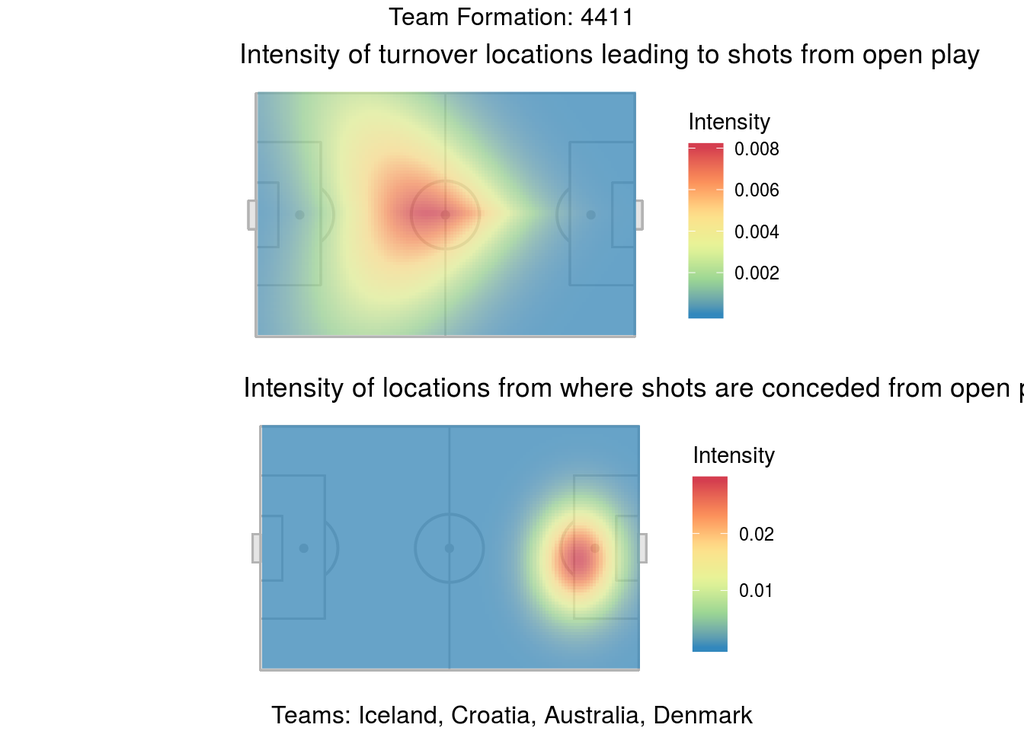

```r
DF.shot.heatmap <- function(DF){

  ### Turnover heatmap
  id <- which(names(pred)==DF)
  pred.mat <- t(as.matrix(pred[[id]]))
  pred.df <- data.frame()
  teamnames <- as.character(unique(shots.full1$DT[shots.full1$DF==as.numeric(DF)]))
  for(i in 1:nrow(pred.mat)){
    for(j in 1:ncol(pred.mat)){
      pred.df = rbind(pred.df,c(i,j,as.numeric((pred.mat)[i,j])))
    }
  }

  colnames(pred.df) <- c("x","y","value")

  G1 <- ggplot(pred.df,aes(x=x,y=y)) +
    annotate_pitch(x_scale = 1.2,
                   y_scale = 0.8,
                   colour = "gray70",
                   fill = "gray90") + theme_pitch()+ geom_raster(aes(fill=value), alpha=0.7) + scale_fill_distiller(palette = "Spectral") +
    labs(fill="Intensity", title=paste("Intensity of turnover locations leading to shots from open play"))


  ### Shot location heatmap
  id <- which(names(pred2)==DF)
  pred.mat <- t(as.matrix(pred2[[id]]))
  pred.df <- data.frame()
  teamnames <- as.character(unique(shots.full1$DT[shots.full1$DF==as.numeric(DF)]))
  for(i in 1:nrow(pred.mat)){
    for(j in 1:ncol(pred.mat)){
      pred.df = rbind(pred.df,c(i,j,as.numeric((pred.mat)[i,j])))
    }
  }

  colnames(pred.df) <- c("x","y","value")

  G2=ggplot(pred.df,aes(x=x,y=y)) +
    annotate_pitch(x_scale = 1.2,
                   y_scale = 0.8,
                   colour = "gray70",
                   fill = "gray90") + theme_pitch()+ geom_raster(aes(fill=value), alpha=0.7) +
    scale_fill_distiller(palette = "Spectral") +
    labs(fill="Intensity",
         title=paste("Intensity of locations from where shots are conceded from open play"))



  #as.data.frame(as.cimg(exp(t(pred.mat))))

  grid.arrange(G1, G2, nrow = 2, top=paste("Team Formation:",DF),
               bottom=paste("Teams:",paste(teamnames,collapse = ", ")))

}

#Running over all formations
for(i in 1:length(formation.interest)){
   DF.shot.heatmap(as.character(formation.interest[i]))
  }
```

### Question 2

Using similar ideas as 1, we again fit inhomogeneous Poisson point process to the pass end locations of goalkeeper passes and mark them by the defensive formation the goalkeeper was playing against.

```r
saves = all.data %>%
  filter(goalkeeper.outcome.name == "Collected" | goalkeeper.outcome.name == "Saved Twice" |
           goalkeeper.outcome.name == "Claim" | goalkeeper.outcome.name == "Collected Twice")

keepers = select(saves,player.name, team.name)
keepers = keepers$player.name

goal_passes = all.data %>% filter(type.name == "Pass", player.name %in% keepers)
```

Below we plot the surface for different formations.

```r
gk.pass.info=function(x){
shot.info <- goal_passes[i,]
attack.team <- shot.info$team.name
defend.team <- c(shot.info$home_team.home_team_name,shot.info$away_team.away_team_name)[!(c(shot.info$home_team.home_team_name,shot.info$away_team.away_team_name) %in% shot.info$team.name)]
tactics.flag.defence <- subset(all.data, (match_id== shot.info$match_id & team.name==defend.team & type.name == "Tactical Shift" & period < shot.info$period) | (match_id== shot.info$match_id & team.id == shot.info$team.id & type.name == "Tactical Shift" & period == shot.info$period & minute <= shot.info$minute & second < shot.info$second))
tactics.flag.attack <- subset(all.data, (match_id== shot.info$match_id & team.name==attack.team & type.name == "Tactical Shift" & period < shot.info$period) | (match_id== shot.info$match_id & team.id == shot.info$team.id & type.name == "Tactical Shift" & period == shot.info$period & minute <= shot.info$minute & second < shot.info$second))
attack.formation <- ifelse(nrow(tactics.flag.attack)>0,tail(tactics.flag.attack$tactics.formation,1),unique(subset(position.data, team.id == shot.info$team.id & match_id == shot.info$match_id)$tactics.formation))
defence.formation <- ifelse(nrow(tactics.flag.defence)>0,tail(tactics.flag.defence$tactics.formation,1),unique(subset(position.data, team.id != shot.info$team.id & match_id == shot.info$match_id)$tactics.formation))
return(list(AT=attack.team,DT=defend.team,DF=defence.formation,AF=attack.formation))
}

gk.att <- unlist(gk.pass.info(1))

for(i in 2:nrow(goal_passes)){
  temp <- rbind(gk.att,gk.pass.info(i))
  gk.att <- temp
  #print(i)
}

goal_passes=data.frame(goal_passes,apply(gk.att,2,as.character))
formation.interest=as.numeric(names(table(goal_passes$DF)[which(table(goal_passes$DF) > 15)]))
goal_passes=subset(goal_passes,DF %in% formation.interest)

PP.gk = ppp (as.numeric(goal_passes$pass.end.x), as.numeric(goal_passes$pass.end.y), c(0,120),c(0,80), marks=factor(goal_passes$DF))
```

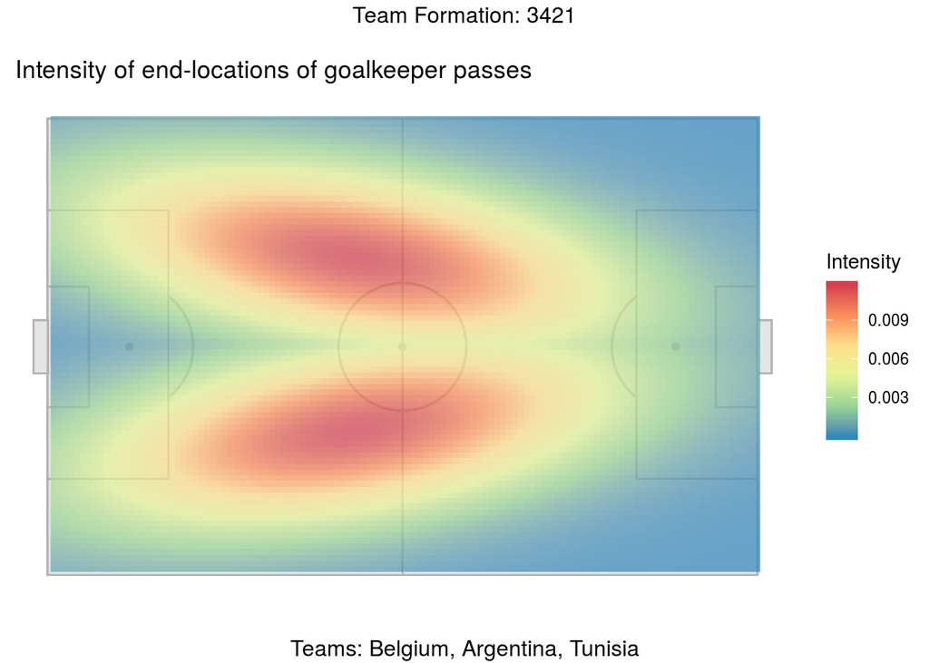

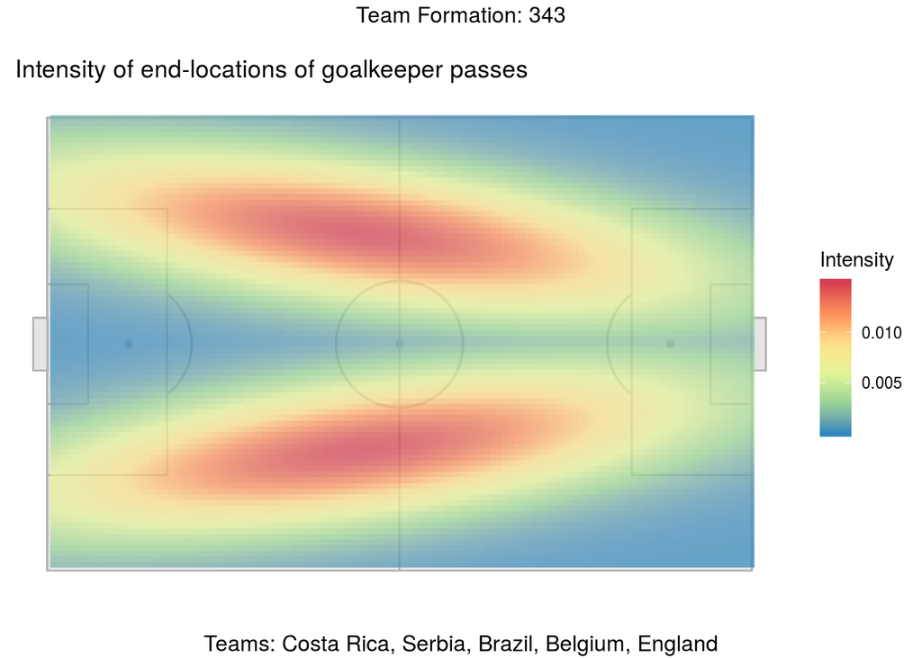

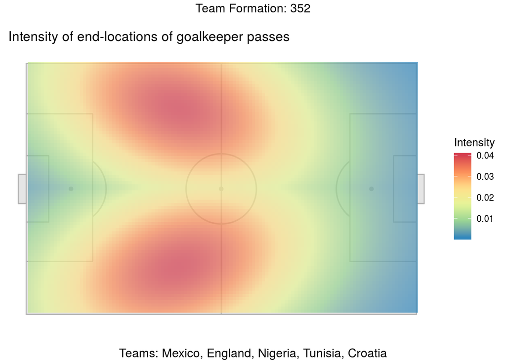

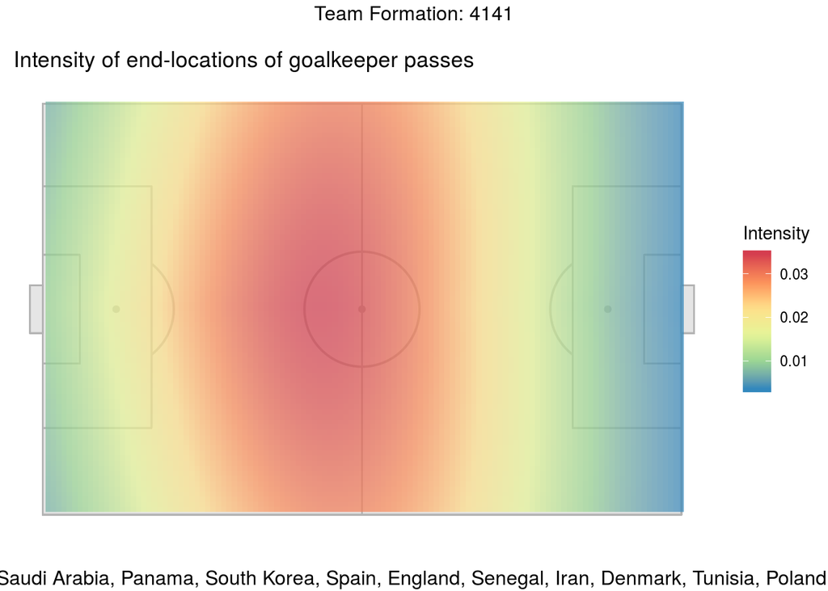

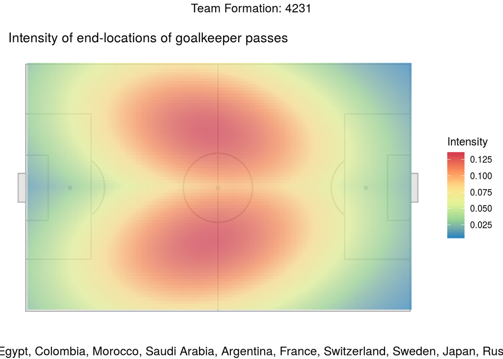

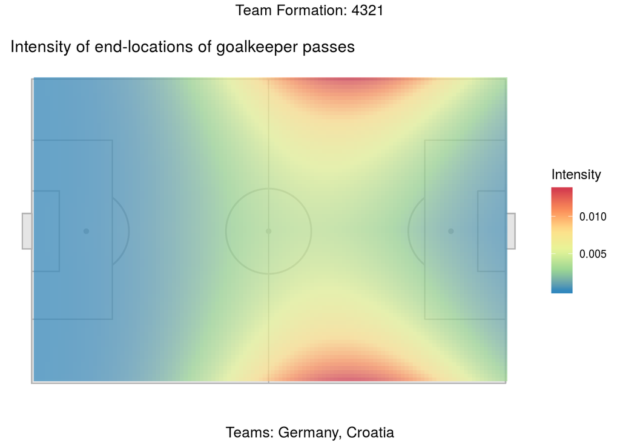

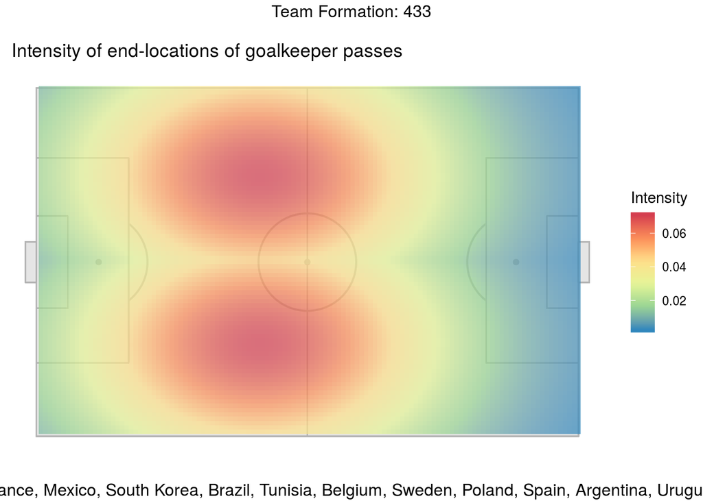

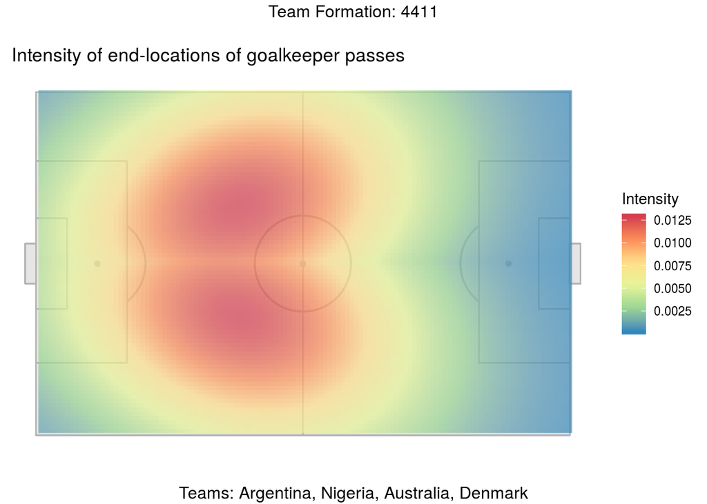

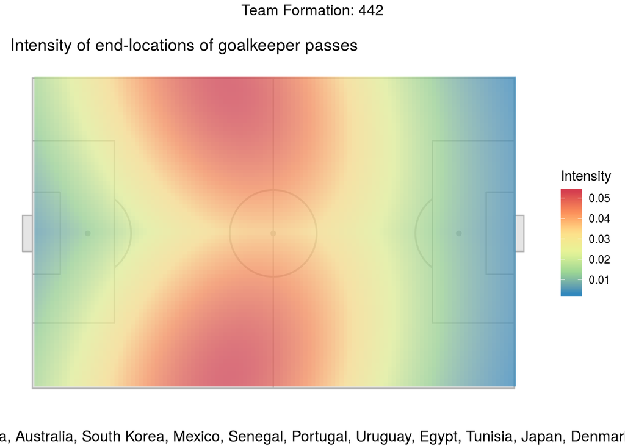

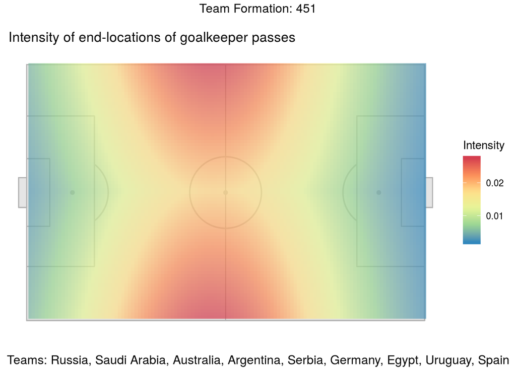

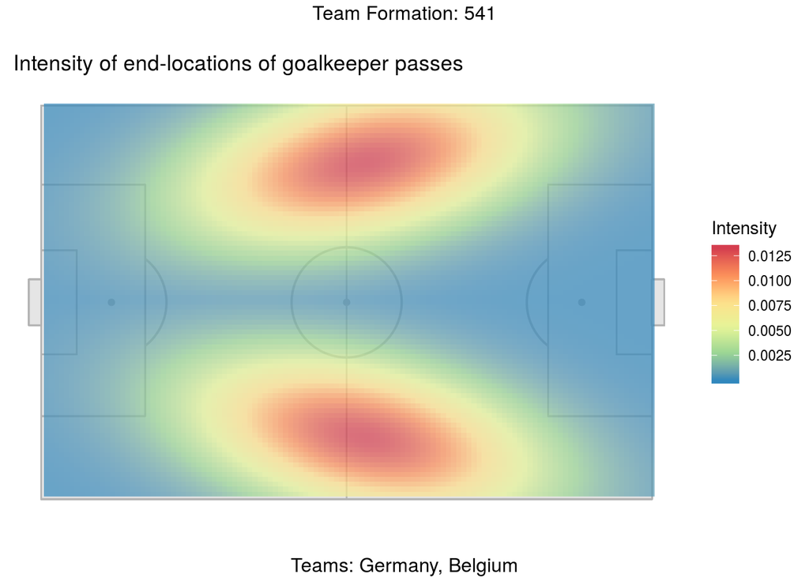

```r
fit.gk=ppm(PP.gk ~  marks*polynom(x,g(y),2), Poisson())

pred3 <- predict(fit.gk,ngrid=c(80,120), type="cif")

DF.gk.heatmap <- function(DF){

  ### Turnover heatmap
  id <- which(names(pred3)==DF)
  pred.mat <- t(as.matrix(pred3[[id]]))
  pred.df <- data.frame()
  teamnames <- as.character(unique(goal_passes$DT[goal_passes$DF==as.numeric(DF)]))
  for(i in 1:nrow(pred.mat)){
    for(j in 1:ncol(pred.mat)){
      pred.df = rbind(pred.df,c(i,j,as.numeric((pred.mat)[i,j])))
    }
  }

  colnames(pred.df) <- c("x","y","value")

  G1 <- ggplot(pred.df,aes(x=x,y=y)) +
    annotate_pitch(x_scale = 1.2,
                   y_scale = 0.8,
                   colour = "gray70",
                   fill = "gray90") + theme_pitch()+ geom_raster(aes(fill=value), alpha=0.7) +
    scale_fill_distiller(palette = "Spectral") +
    labs(fill="Intensity",
         title=paste("Intensity of end-locations of goalkeeper passes"))
  #as.data.frame(as.cimg(exp(t(pred.mat))))

  grid.arrange(G1, nrow = 1, top=paste("Team Formation:",DF),
               bottom=paste("Teams:", paste(teamnames,collapse = ", ")))

}

#Running over all formations
for(i in 1:length(formation.interest)){
   DF.gk.heatmap(as.character(formation.interest[i]))
 }
```

### Question 3

Can we develop team level summary measures from possession sequences that are reflective of team performance? Data with such a fine grain of temporal detail can quickly become overwhelming. Summary measures such as these would be tremendously useful for a soccer club.

This is a complex question to answer and we think breaking the game into a string of possession sequences is the way to answer it. So, as a next step, we find out each possession sequence and define a few statistics which can characterize that particular possession sequence -

1. Timespan: The duration of the possession sequence
2. Passcount: Number of successful passes played in a possession sequence.
3. Time under pressure: The duration the possessing team was under pressure from the defensive team.
4. Pass under pressure: Number of successful passes played by the possessing team under pressure.
5. Chull area: The area of the convex hull created by the points representing players of the possessing team in that sequnece, its expected to reflect the area over which the possessing team attacked.
6. Distance to goal: Distance of the closest point in the possession sequence from the midpoint of goal.
7. Vertical distance travelled: The difference in $x$-coordinates of the end location and the start location of the possession sequence, which gives the vertical distance travelled by the possessing team.

For $i$ the possession, we define two outcomes $Y_i$ and $Z_i$(expected gaol from possession) as follows: $Y_i= \mathbb{1}$[shot happened from the $i$-th possession] and $Z_i= Y_i * G_i + (1-Y_i)*0$, where $G_i$ is the Statsbomb expected goal statistic (xG) if $i$-th possession led to a shot. Let, $X_i$ denote the covariate vector (including intercept) as defined above.

We model this as follows:

$logit(P(Y_i=1|X_i))=X_i\beta_1$ $G_i | Y_i= 1 ~ Gamma(\alpha,\delta_i)$, where $1/\delta_i= X_i\beta_2$.

We use the data created in exploratory analysis to fit the model. We seperate the data into train ($70\%$) and test ($30\%$) to model evaulation. We don’t consider penalties and huge errors which gives rise to xGs which are outliers.

```r
pc.data.clean$xG[pc.data.clean$shot==0]=0

### Removing penalties and errors which give rise to bigger xGs
xG.out <- boxplot.stats(pc.data.clean$xG[pc.data.clean$xG!=0], coef=5)$out
pc.complete=subset(pc.data.clean,complete.cases(pc.data.clean) & ! xG %in% xG.out)
pc.res=prcomp(pc.complete[,-c(1:6)],scale=TRUE)

pc.complete$PC1=pc.res$x[,1]
pc.complete$PC2=pc.res$x[,2]


## random training data
### Running random forest for prediction
set.seed(12345)
train_id <- createDataPartition((pc.complete$shot)!=0, p = 0.7,
                                list = FALSE,
                                times = 1)

train <- pc.complete[train_id, ]
test  <- pc.complete[-train_id, ]

fit.glm <-glm((shot!=0) ~ timespan + pass.length + pass.speed + I(time.under.pressure/timespan) + I(pass.under.pressure/passcount) + passcount + chull.area + dist.to.goal + vert.dist, data=train, family=binomial())
fit.glm <- step(fit.glm)
```

```
## Start:  AIC=2162.23
## (shot != 0) ~ timespan + pass.length + pass.speed + I(time.under.pressure/timespan) +
##     I(pass.under.pressure/passcount) + passcount + chull.area +
##     dist.to.goal + vert.dist
##
##                                    Df Deviance    AIC
## - vert.dist                         1   2143.0 2161.0
## - timespan                          1   2143.8 2161.8
## - I(pass.under.pressure/passcount)  1   2144.0 2162.0
## <none>                                  2142.2 2162.2
## - pass.speed                        1   2146.2 2164.2
## - pass.length                       1   2152.9 2170.9
## - I(time.under.pressure/timespan)   1   2154.6 2172.6
## - chull.area                        1   2155.4 2173.4
## - passcount                         1   2164.4 2182.4
## - dist.to.goal                      1   3762.2 3780.2
##
## Step:  AIC=2160.98
## (shot != 0) ~ timespan + pass.length + pass.speed + I(time.under.pressure/timespan) +
##     I(pass.under.pressure/passcount) + passcount + chull.area +
##     dist.to.goal
##
##                                    Df Deviance    AIC
## - timespan                          1   2144.8 2160.8
## - I(pass.under.pressure/passcount)  1   2144.8 2160.8
## <none>                                  2143.0 2161.0
## - pass.speed                        1   2147.1 2163.1
## - pass.length                       1   2154.2 2170.2
## - chull.area                        1   2155.4 2171.4
## - I(time.under.pressure/timespan)   1   2155.5 2171.5
## - passcount                         1   2164.8 2180.8
## - dist.to.goal                      1   3843.6 3859.6
##
## Step:  AIC=2160.76
## (shot != 0) ~ pass.length + pass.speed + I(time.under.pressure/timespan) +
##     I(pass.under.pressure/passcount) + passcount + chull.area +
##     dist.to.goal
##
##                                    Df Deviance    AIC
## <none>                                  2144.8 2160.8
## - I(pass.under.pressure/passcount)  1   2146.8 2160.8
## - pass.speed                        1   2149.0 2163.0
## - pass.length                       1   2155.5 2169.5
## - chull.area                        1   2158.3 2172.3
## - I(time.under.pressure/timespan)   1   2159.4 2173.4
## - passcount                         1   2171.1 2185.1
## - dist.to.goal                      1   3871.9 3885.9
```

```r
fit.pred <- predict(fit.glm, test, type="response")
test <- data.frame(test,fit.pred)
pROC::roc(test$shot!=0 ~ fit.pred)
```

```
##
## Call:
## roc.formula(formula = test$shot != 0 ~ fit.pred)
##
## Data: fit.pred in 1779 controls (test$shot != 0 FALSE) < 382 cases (test$shot != 0 TRUE).
## Area under the curve: 0.9502
```

```r
fit.xg <- glm(xG ~ timespan + pass.length + pass.speed + I(time.under.pressure/timespan) + I(pass.under.pressure/passcount) + passcount + chull.area + dist.to.goal + vert.dist, data=subset(train,shot != 0), family=Gamma())
fit.xg <- step(fit.xg)
```

```
## Start:  AIC=-2902.87
## xG ~ timespan + pass.length + pass.speed + I(time.under.pressure/timespan) +
##     I(pass.under.pressure/passcount) + passcount + chull.area +
##     dist.to.goal + vert.dist
##
##                                    Df Deviance     AIC
## - I(time.under.pressure/timespan)   1   676.99 -2904.9
## - pass.length                       1   677.04 -2904.8
## - pass.speed                        1   677.34 -2904.4
## - passcount                         1   677.50 -2904.2
## - timespan                          1   677.51 -2904.2
## - vert.dist                         1   677.85 -2903.8
## - I(pass.under.pressure/passcount)  1   678.24 -2903.3
## - chull.area                        1   678.48 -2903.1
## <none>                                  676.98 -2902.9
## - dist.to.goal                      1   950.85 -2573.6
##
## Step:  AIC=-2904.86
## xG ~ timespan + pass.length + pass.speed + I(pass.under.pressure/passcount) +
##     passcount + chull.area + dist.to.goal + vert.dist
##
##                                    Df Deviance     AIC
## - pass.length                       1   677.04 -2906.8
## - pass.speed                        1   677.35 -2906.4
## - passcount                         1   677.52 -2906.2
## - timespan                          1   677.56 -2906.2
## - vert.dist                         1   677.87 -2905.8
## - chull.area                        1   678.48 -2905.1
## <none>                                  676.99 -2904.9
## - I(pass.under.pressure/passcount)  1   678.76 -2904.7
## - dist.to.goal                      1   951.98 -2573.8
##
## Step:  AIC=-2906.78
## xG ~ timespan + pass.speed + I(pass.under.pressure/passcount) +
##     passcount + chull.area + dist.to.goal + vert.dist
##
##                                    Df Deviance     AIC
## - pass.speed                        1   677.36 -2908.4
## - timespan                          1   677.62 -2908.1
## - passcount                         1   677.71 -2908.0
```

[output cut: 38 more lines]

```
## <none>                                  677.92 -2911.5
## - chull.area                        1   685.06 -2904.8
## - dist.to.goal                      1   960.24 -2571.8
##
## Step:  AIC=-2911.88
## xG ~ I(pass.under.pressure/passcount) + chull.area + dist.to.goal
##
##                                    Df Deviance     AIC
## - I(pass.under.pressure/passcount)  1   680.65 -2911.9
## <none>                                  679.01 -2911.9
## - chull.area                        1   685.06 -2906.6
## - dist.to.goal                      1   968.87 -2563.1
##
## Step:  AIC=-2911.47
## xG ~ chull.area + dist.to.goal
```

```r
fit.xg.pred <- predict(fit.xg, test, type="response")
test <- data.frame(test, xg.pred=fit.pred*fit.xg.pred)
mean(((test$xG) - fit.xg.pred)^2)
```

```
## [1] 0.002095651
```

```r
##### Scoring each possession sequence
pc.data$xSP = predict(fit.glm, pc.data, ty="response")
pc.data$xGP= pc.data$xSP * predict(fit.xg, pc.data, ty="response")
```

We use backward selection to get optimum set of predictors and observe a test set AUC of $0.95$ and mean-squared error of $0.002$. We did this for different seeds and observed similar results.

Once we validate the prediction power of this model, we predict two numbers for each possession sequence in the world cup as follows:

$xPSP_i= \hat{P(Y_i=1|X_i)}$ and $xPGP_i=\hat{P(Y_i=1|X_i)} * \hat{E(G_i|Y_i=1,X_i)}$.

Now, we define $P_M^A(t)$ to be the set of possessions that happened before time $t$ when team $M$ was in attack and $P_M^D (t)$ be the set of possessions that happened before time $t$, then we define two statistics as follows:

$nPSP_M (t)=\sum_{i \in P_M^A(t)} xPSP_i - \sum_{i \in P_M^D(t)} xPSP_i$ and $nPGP_M(t)=\sum_{i \in P_M^A(t)} xPGP_i - \sum_{i \in P_M^D(t)} xPGP_i$. These two variable which varies over time $t$ sort of gives us an idea about the match control coefficient for a certain team at time $t$.

We built a shiny app here, which shows for a certain match the plot of how these two coefficients vary over time: [shiny app](https://apita.shinyapps.io/football_analytics_dashboard/)

# Narrative and Summary

We set out to use data from the 2018 FIFA World Cup to develop tools and insights about the game of soccer that could be useful to a soccer club manager or coach. As compared to other professional sports, such as baseball, basketball, or (American) football, soccer has fewer “success” events that can be measured. For example, in baseball most teams will score at least a few runs per game, most batters will get at least one hit, and most pitchers will have a handfull of strikeouts. Similarly, in basketball players will have points in the double digits, a shooting percentage between 20 and 50%, and a handfull of rebounds, assists, or steals. In soccer however, it’s not uncommon for only one or two goals to be scored in the whole game, passes are often intercepted or lost out of bounds, and possession of the ball changes hands very often. Thus, applying data analysis to the game of soccer requires a different approach than those used in baseball or basketball.